# RESOLUCIÓN_PARCIAL

Pierina Isabel Tuanama Satalaya

2/8/2021

# DESARROLLO

## PARTE 1

**1.Se tiene una variable x (no necesariamente temperatura) que depende de la elevacion.Se sabe que entre los 1000 y 3000 esta variable se ve reducido en 2 unidades cada 500 metros. Entre los 3000 y 4000 metros, varıa en 0.5 unidades, y a una altitud mayor, su valor es constante.Cree una funcion que permita obtener el valor de esta variable, ́unicamente con el dato de la elevacíon.** **El valor de la variable x a 1000 metros es de 81.4 unidades**

```r
variable <-function(x){
  if( x== 1000){
    a = 81.4
    print(a)
  } else if ( x %in% 1000:1500){
    a = 81.4
    print(a)
  } else if ( x %in% 1500:2000){
    a = 81.4 - 2
    print(a)
  } else if (x %in% 2000:2500) {
    a = 81.4 - 4
    print(a)
  } else if (x %in% 2500:3000){
    a = 81.4 - 6
    print(a)
  } else if (x %in% 3000:3500){
    a = 81.4 - 8.5
    print(a)
  } else if (x %in% 3500:4000){
    a = 81.4 - 9
    print(a)
  } else if (x > 4000){
    a= 81.4-9
    print(a)
  } else {
    print("coloque un valor mayor o igual a 1000")
  }
}
```

**2. Resolver el sistema de ecuaciones**

$3a + 2b - 2c = 0\\2a - 1b + 3c = 9\\a + 4b + 2c = -4$

```r
k <- matrix(c(3,2,1,2,-1,4,-2,3,2), ncol=3, nrow=3)
l <- c(0,9,-4)
solve(k,l)
```

```
## [1]  2 -2  1
```

## PARTE 2

**1. A partir del conjunto de datos:**

Primero debemos cargar la data a trabajar

```r
library(tidyverse)
data1 <- as_tibble(read.csv("mods_clima_uh.csv"))
```

a.Calcular la precipitacíon acumulada anual (Valores observados) para la cuenca asignada

```r
ppacmu <- data1 %>% dplyr::select(uh_name, bh_month , bh_pc , bh_esc) %>%
  dplyr::filter(uh_name == "Cuenca Tumbes" , bh_esc == "Observado")%>%
  summarise(ppacum = sum(bh_pc, na.rm = T))
ppacmu
```

```
## # A tibble: 1 x 1
##   ppacum
##    <dbl>
## 1   852.
```

b.Calcular el porcentaje de sesgo (% PBIAS) de los escenarios climàticos(ACCESS, HADGEM2 , MPI) respecto a los datos observados para cada mes ( enero- diciembre) de cada variable, para la cuenca asignada

```r
data5 <- data1 %>% dplyr::select(uh_name, bh_month , bh_pc , bh_esc)%>%
  dplyr::filter(uh_name == "Cuenca Tumbes")%>%
  pivot_wider(names_from = "bh_esc", values_from = "bh_pc")
library(hydroGOF)
(OB_ACCES <-pbias(data5$`ACCESS 1.0` , data5$Observado , na.rm = T))
```

```
## [1] 25.9
```

```r
(OB_HadGE <-pbias(data5$`HadGEM2-ES` , data5$Observado , na.rm = T))
```

```
## [1] 13.8
```

```r
(OB_MPIEM <-pbias(data5$`MPI-ESM-LR` , data5$Observado , na.rm = T))
```

```
## [1] -1.5
```

c.De la anterior, ¿Cuàl es el escenario climàtico màs preciso? Fundamente su respuesta.

-el modelo mejor estiamdo es el MPI-ESM-LR ya que tiene un valor cercano a 0 que es el optimo pero su valor negativo nos indica una subestimacion del modelo.

d.Graficar, con ggplot2, la precipitaciòn (enero a diciembre) observada y modelo climàticos.

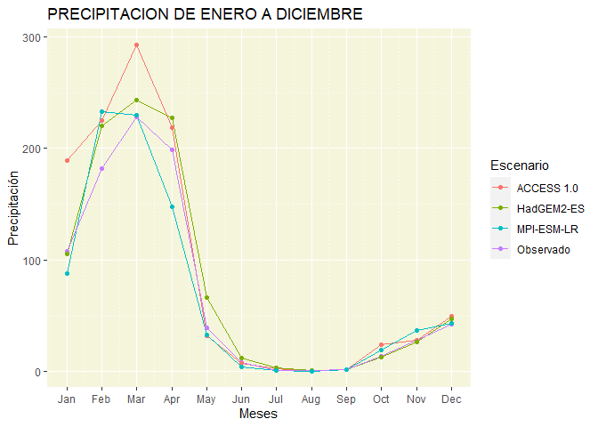

```r
data4 <- data1 %>% dplyr::select(uh_name, bh_month , bh_pc , bh_esc) %>%
  dplyr::filter(uh_name == "Cuenca Tumbes")%>%
  rename(Cuenca = uh_name , month = bh_month , pp = bh_pc, Escenario = bh_esc)

ggplot(data4,
       mapping = aes(x = month,
                     y = pp,
                     color = Escenario))+
  geom_line()+
  geom_point()+
  scale_x_continuous(
    breaks = c(1:12),
    labels = month.abb,
  )+
  theme(
    panel.background = element_rect(fill = "beige"),
    panel.grid.minor = element_line(linetype = "dotted")
  )+
  ggtitle("PRECIPITACION DE ENERO A DICIEMBRE")+
  labs(x = "Meses",
       y = "Precipitación")
```

## PARTE 3

**1.Se tiene el conjunto de datos de temperatura diaria(periodo 1928 - 2015 ) de ciertas estaciones metereològicas (temperatureDataset.csv), donde cad una de estas estàsn asociadas a un còdigo ùnico(p.eqc00000208). Si existen valores iguales a -99.9, considerarlos como missing values y convertirlos en NA.**

Se solicita:

a.Determine la cantidad de missing values para los años hidrologicos Sep1983-Agos1984 y Sep1997-Agost1998

```r
data2 <- as_tibble(read.csv("temperatureDataset.csv", na.strings = -99.9))

data3 <- data2 %>% select(DATE, qc00000805)%>%
  mutate(DATE = as.Date(DATE, format = "%d/%m/%Y"))%>%
  rename(temp = qc00000805)%>%
  arrange(DATE)

data3 %>% dplyr::filter(DATE >="1983-09-01" , DATE <="1984-08-31" |DATE >="1997-09-01" , DATE <="1997-09-01") %>%
  summarise( miss_invalue =sum(is.na(temp)))
```

```
## # A tibble: 1 x 1
##   miss_invalue
##          <int>
## 1            1
```

b.Calcule la serie de tiempo de temperatura mensual ( si el de dias con missing values), en un mes, supera el 5%, la temperatura mensual seria considerado como un NA) mas, identifique,visualmente, posibles atipicos y describa una posible causa.

```r
data6 <- data3 %>%  group_by(DATE = str_sub(DATE, 1, 7)) %>%
  mutate(missVal = sum(is.na(temp)) * 100 / n()) %>%
  summarize(
    temp = mean(temp , na.rm = T),
    missVal = unique(missVal)
    ) %>%
  mutate(temp = ifelse(missVal >=5 , NA , temp),
         DATE = as.Date(sprintf("%1$s-01", DATE)),
         month= str_sub(DATE, 6, 7)
         )
data6
```

```
## # A tibble: 1,044 x 4
##    DATE        temp missVal month
##    <date>     <dbl>   <dbl> <chr>
##  1 1928-11-01    NA     100 11
##  2 1928-12-01    NA     100 12
##  3 1929-01-01    NA     100 01
##  4 1929-02-01    NA     100 02
##  5 1929-03-01    NA     100 03
##  6 1929-04-01    NA     100 04
##  7 1929-05-01    NA     100 05
##  8 1929-06-01    NA     100 06
##  9 1929-07-01    NA     100 07
## 10 1929-08-01    NA     100 08
## # ... with 1,034 more rows
```

```r
summary(data6)
```

```
##       DATE                 temp          missVal          month
##  Min.   :1928-11-01   Min.   :22.61   Min.   :  0.00   Length:1044
##  1st Qu.:1950-07-24   1st Qu.:24.78   1st Qu.:  0.00   Class :character
##  Median :1972-04-16   Median :25.46   Median :  0.00   Mode  :character
##  Mean   :1972-04-16   Mean   :25.49   Mean   : 28.27
##  3rd Qu.:1994-01-08   3rd Qu.:26.21   3rd Qu.:100.00
##  Max.   :2015-10-01   Max.   :28.75   Max.   :100.00
##                       NA's   :353
```

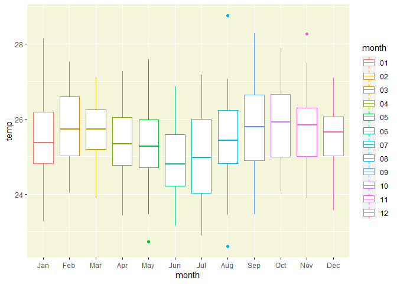

```r
ggplot()+
  geom_boxplot(data6 , mapping = aes( x = month , y = temp , color = month))+
  scale_x_discrete(
    labels = month.abb,
  )+theme(
    panel.background = element_rect(fill = "beige"),
  )
```

c.Determine la cantidad de missing values de la serie de tiempo a paso mensial para los años a 2005 y 2010.

```r
data6 %>% dplyr::filter(DATE >="2005-01-01" , DATE <="2010-12-01") %>%
  summarise( miss_invalue =sum(is.na(temp)))
```

```
## # A tibble: 1 x 1
##   miss_invalue
##          <int>
## 1            0
```

d.Cree una funcion que calcule, a partir de los datos de temperatura mensual, la climatologìa (Ene-Dic). Obtener la climatologia para los periodos 1980-1995 y 1996-2010.Plotear sus resultados en una sola gràfica para describir sus diferencias y/o similitudes (entre climatologìas)

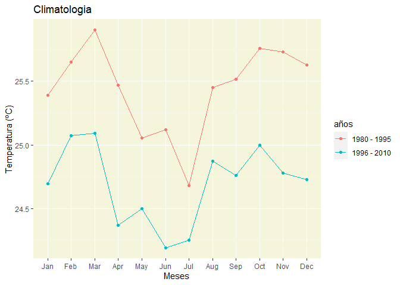

```r
prueba1 <- function(data,year1,year2){
  data %>% mutate( año= as.integer(str_sub(DATE, 1,4))) %>%
    dplyr::filter(año %in% year1:year2) %>%
    group_by(month) %>%
    summarise(tempmean =mean(temp,na.rm = T)) %>%
    mutate(años = sprintf( "%1s - %1s" , year1 , year2))
  }

pur <-prueba1(data6,1980,1995)
par <-prueba1(data6,1996,2010)
ejer_f <-rbind(pur,par)

ggplot(ejer_f,
       mapping = aes(x = month,
                     y = tempmean,
                     group=años,
                     color= años))+
  geom_line()+
  geom_point()+
  scale_x_discrete(
    labels = month.abb,
  )+
  theme(
    panel.background = element_rect(fill = "beige"),
    panel.grid.minor = element_line(linetype = "dotted")
  )+
  ggtitle("Climatologia")+
  labs(x = "Meses",
       y = "Temperatura (ºC)")
```

e.Plotear (boxplot) la variablidad de los valores mensuales (Ene-Dic) para el periodo 1980-2013 y describirlo correctamente.

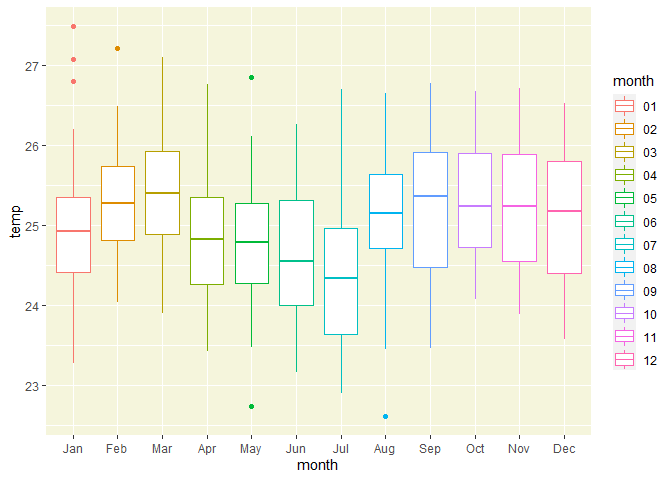

```r
ejer_3e <-data6 %>% filter( DATE >="1980-01-01" & DATE <= "2013-12-1")
ggplot()+
  geom_boxplot(ejer_3e, mapping = aes( x = month , y = temp , color = month))+
  scale_x_discrete(
    labels = month.abb,
  )+theme(
    panel.background = element_rect(fill = "beige"),
  )
```